# Question 2: Please stay in Cape Town

Austin Byrne

June 2023

### Abstract

Please dont move to England, the whether is not as nice as you think and i am here to show you with some graphs.

```r
knitr::opts_chunk$set(echo = FALSE, message=FALSE, warning=FALSE)
pacman::p_load(modelsummary, gt, knitr, kableExtra, tidyverse)

install.packages("tinytex")
library(tinytex)
tinytex::install_tinytex()
```

```r
library(tidyverse)
list.files('C:/Users/austi/OneDrive/Desktop/Masters/Data Science/22582053/Question 2/code', full.names = T, recursive = T) %>% as.list() %>% walk(~source(.))
```

# Introduction

I will be showing you the max, average and min temerature averages through the past several years, I will then illustrtate how much sun on average London gets looking at the past several year and then looking soely on the year of 2020.

# 1 Data

```r
library(readr)
london_weather <- read_csv("C:/Users/austi/OneDrive/Desktop/Masters/Data Science/22582053/Question 2/data/london_weather.csv")
```

## 1.1 creating data frame with max, min and average

```r
library(ggplot2)
library(dplyr)
library(lubridate)


london_max_mean_min <- london_weather_trends(london_weather)
```

## 1.2 Plotting the max, min and average

[figure not shown]

```r
temp_trend_plot(london_max_mean_min)
```

## 1.3 Looking at the amount of sunshine london gets

## 1.4 Creating a data frame with sunshine

```r
london_sunshine <- calculate_avg_sunshine(london_weather)
```

## 1.5 Ploting hours of sunshine per day on average

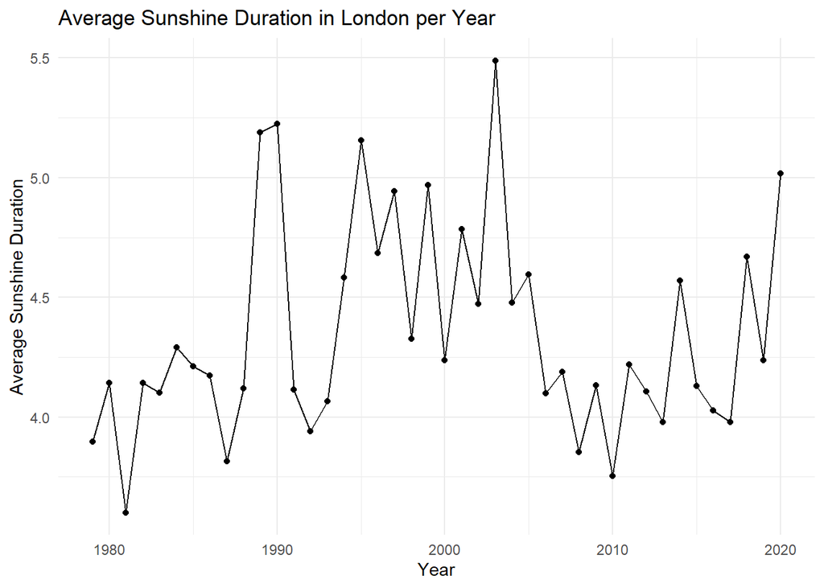

```r
plot_avg_sunshine(london_sunshine)
```

As can be seen from the above figure there are many years that receive less than 5 to 7 hpurs of sunchine a day on average. I know you wont enjoy that. You may be saying that recently it has been getting better, that is why I have made the next plot.

## 1.6 Plotting London hours of sunshine per day for 2020

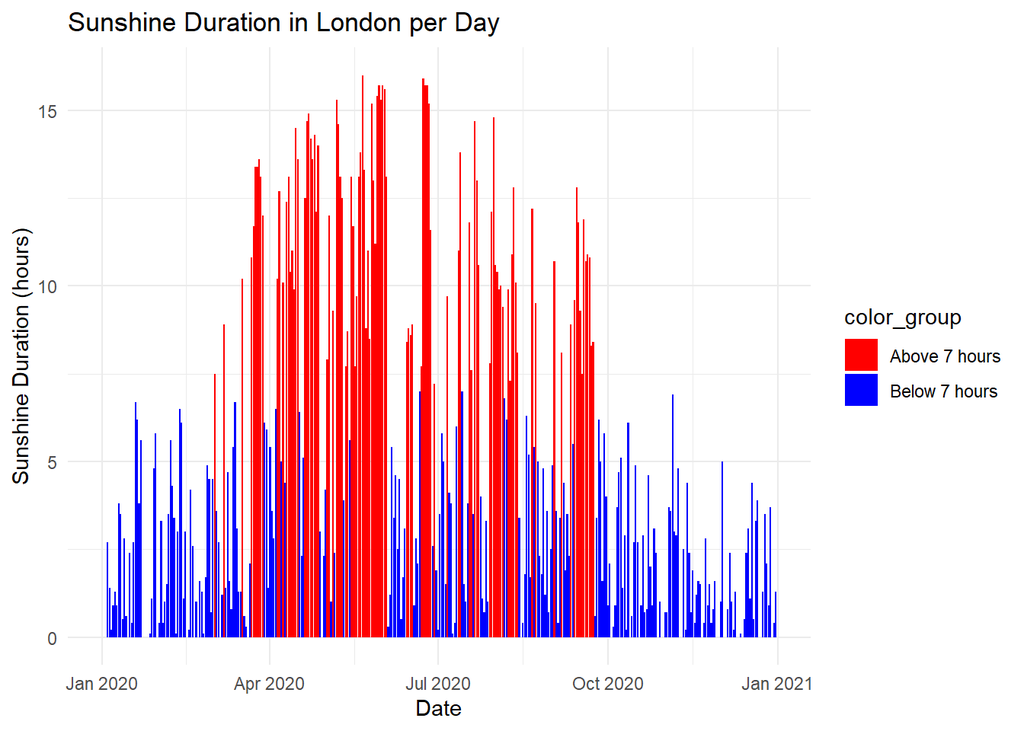

```r
london_sunshine_last_year<- london_weather %>%
    arrange(date) %>%
    mutate(date = as.Date(as.character(date), format = "%Y%m%d")) %>%
    filter(date>= lubridate::ymd("20200101"))

plot_sunshine_per_day(london_sunshine_last_year)
```

From the above figure the red lines show days where there was sunshine for over 7 overs and the blue lines show days throughout the year where there was less than 7 hours of sunshine. As you can see there are way too many days (which can be consecutive) where there is less than 7 hours of sun.

# 2 Conclusion

PLease stay, there is not enough sun and the temp is way too cold for you.